# Reproducible Research: Peer Assessment 1

This markdown file analyzes the data provided for Peer Assessment 1 of the Coursera Reproducible Research course. The data comes from a personal activity monitoring device, collected at 5 minute intervals throughout the day. This was done for an anonymous individual over 2 months in October and November of 2012. The data includes the number of steps the individual took throughout each 5 minute interval.

This analysis will later require functions in the lattice and reshape2 packages, so we load them here at the beginning.

```r
require(lattice, quietly=TRUE)
require(reshape2, quietly=TRUE)
```

## Loading and preprocessing the data

The data set first needs to be unzipped. It can then be loaded into a data frame. The variable classes for each column are set manually to avoid confusion, as is the presence of a header line.

```r
unzip("activity.zip")
activity<-read.csv("activity.csv",header=TRUE,colClasses=c("numeric","Date","numeric"))
```

## What is mean total number of steps taken per day?

In order to avoid the effect of NA values in the data set, we first define a utility function that will perform the sum over non-NA inputs.

```r
noNAsum <- function (x) { sum(x, na.rm = TRUE) }
```

We then use this to sum the number of steps taken each day by treating the activity$date variable as a factor.

```r
stepSum <- tapply(activity$steps,factor(activity$date),noNAsum)
```

A histogram shows the distribution of the number of steps each day.

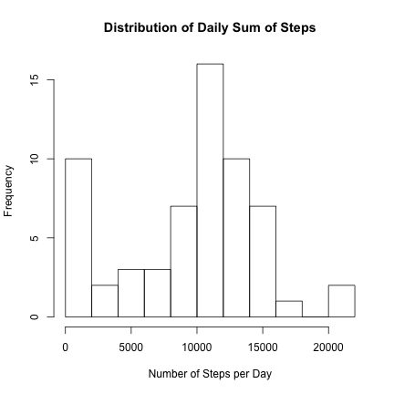

```r
hist(stepSum,breaks=10,xlab="Number of Steps per Day",
     main="Distribution of Daily Sum of Steps")
```

The mean and median number of total steps per day can also be computed.

```r
meanSteps <- mean(stepSum)
medSteps <- median(stepSum)
```

We find that the mean is 9354.2295 steps/day and the median is 1.0395 × 10<sup>4</sup> steps/day.

## What is the average daily activity pattern?

To look at the average daily activity pattern, we will first define a utility function much like we did for the sum, only now to perform the mean while ignoring any NA values.

```r
noNAmean <- function (x) { mean(x, na.rm = TRUE) }
```

We can then apply this to the original data and treat the 5-minute interval as a factor. This will provide us with the average number of steps taken in each time interval over all days in the data set. The result is then converted into a data frame.

```r
stepMean <- with(activity, tapply(steps,factor(interval), noNAmean))
stepMean <- melt(stepMean)
names(stepMean) <- c("interval","steps")
```

A line plot provides us with a visualization of this average trend over the day.

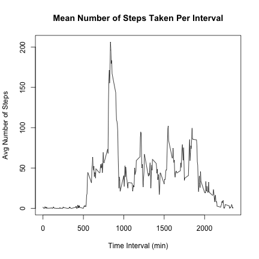

```r
plot(stepMean$interval, stepMean$steps, type="l", xlab="Time Interval (min)",
     ylab="Avg Number of Steps", main="Mean Number of Steps Taken Per Interval")
```

To find the time interval in which the most steps were taken on average, we first find the maximum number of steps. We then match this with its corresponding interval.

```r
maxSteps <- max(stepMean$steps)
maxStepInt <- stepMean$interval[stepMean$steps == maxSteps]
```

This tells us that the maximum average number of steps taken in a 5-minute interval is 206.1698 steps in the 5-minute interval beginning at 835 minutes.

## Imputing missing values

This data set contains many NA values which may introduce some bias in our previous measurements. First, let's see how many there are in the data set.

```r
numNA <- sum(is.na(activity$steps))
```

This reports that there are 2304 NA values present out of the 17,568 total number of observations. To fill in these values, we use the mean number of steps taken for the given interval, as computed in the previous section of this analysis. First we copy the original data frame to a new variable; this is then edited to fill in the missing values.

```r
activityFill <- activity
for (i in seq(1,length(activityFill$steps),by=1)) {
        if (is.na(activityFill$steps[i])) {
                newsteps <- stepMean$steps[stepMean$interval==activityFill$interval[i]]
                activityFill$steps[i] <- newsteps
        }
}
```

With this filled-in data set, we now look again at the distribution of the total number of steps taken per day, including its mean and median values.

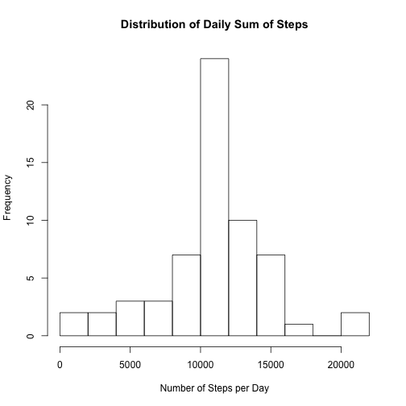

```r
stepFillSum <- tapply(activityFill$steps,factor(activityFill$date),noNAsum)
meanStepsFill <- mean(stepFillSum)
medStepsFill <- median(stepFillSum)
hist(stepFillSum,breaks=10,xlab="Number of Steps per Day",
     main="Distribution of Daily Sum of Steps")
```

We thus obtain a mean of 1.0766 × 10<sup>4</sup> steps/day and a median of 1.0766 × 10<sup>4</sup> steps/day. These values are different from before. As the NAs tend to come in whole-day groups, we have essentially added in entire days with the average number of steps taken in each interval. The total number of steps then has multiple additions of the same value. This skews both the mean and median to the same value. We have also filled in incomplete days, thus removing some of the days that had lower totals due to the missing values.

## Are there differences in activity patterns between weekdays and weekends?

In our final analysis, we want to consider the difference in activity between weekdays (Monday to Friday) and weekends (Saturday and Sunday). To do this, we begin by creating a new factor variable in our filled-in dataset that indicates whether a day is a weekday or on the weekend.

```r
activityFill$weekday <- weekdays(activityFill$date)
activityFill$weekday[which(activityFill$weekday %in% c("Saturday","Sunday"))] <- "weekend"
activityFill$weekday[which(activityFill$weekday != "weekend")] <- "weekday"
activityFill$weekday <- factor(activityFill$weekday)
```

This code initially converts the dates to weekday names and saves these as the new variable. It then replaces all occurrences of “Saturday” or “Sunday” with “weekend”. Then, all those that were not replaced to “weekend” are made “weekday”. Lastly, the variable is converted to a factor which will have 2 levels.

To compare the average activity over weekdays versus weekends, we first compute this average activity. This is averaged within both the weekday/weekend factor and the time interval factor.

```r
stepFillMean <- with(activityFill, tapply(steps, list(factor(interval), weekday), noNAmean))
stepFillMean <- melt(stepFillMean)
names(stepFillMean) <- c("interval", "weekday", "steps")
```

A plot comparing the average trends of weekends vs weekdays will show us if there is any difference in activity pattern between them. This plot requires the lattice package.

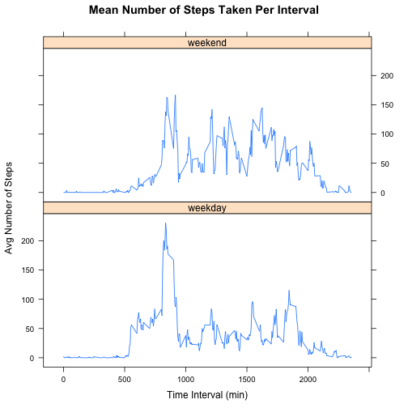

```r
xyplot(steps ~ interval | weekday, data = stepFillMean, type = "l",
       layout = c(1,2), xlab="Time Interval (min)",
       ylab="Avg Number of Steps", main="Mean Number of Steps Taken Per Interval")
```

From this plot, we can see some differences in activity patterns between the average weekday and weekend. Most noticeably, the subject was active earlier in the morning on weekdays, presumably in order to go to a job. Similarly, activity continues until a later time on the weekend, possibly while out at social activities.